# Data Visualizations

## More combinations

```r
ggplot(data = HELP_data,
       aes(x = age)) +
  geom_point(stat = "bin",
             binwidth = 3,
             aes(size = ..count..)) +
  geom_line(stat = "bin", binwidth = 3) +
  labs(title = "HELP clinical trial at detoxification unit")
```

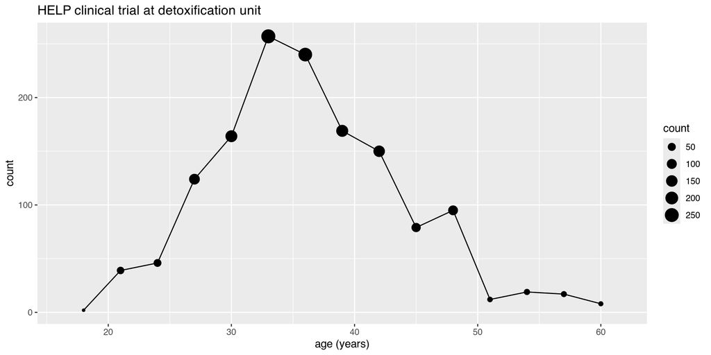

## How much drinking? (i1)

```r
HELP_data |>
  ggplot(aes(x = i1)) + geom_histogram() +
  labs(title = "HELP clinical trial at detoxification unit")
```

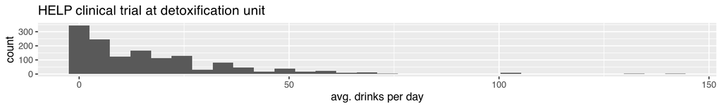

## How much drinking? (i1)

```r
HELP_data |>
  ggplot(aes(x = i1)) + geom_density() +
  labs(title = "HELP clinical trial at detoxification unit")
```

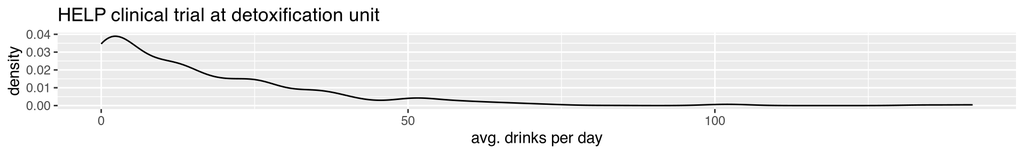

## How much drinking? (i1)

```r
HELP_data |>
  ggplot(aes(x = i1)) + geom_area(stat = "density") +
  labs(title = "HELP clinical trial at detoxification unit")
```

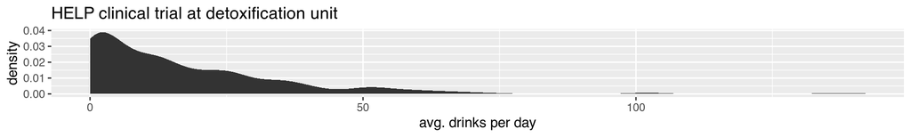

## Covariates: Adding in more variables

Using color and linetype:

```r
ggplot(data = HELP_data,
       aes(x = i1,
           color = substance,
           linetype = children)) +
  geom_line(stat = "density") +
  labs(title = "HELP clinical trial at detoxification unit")
```

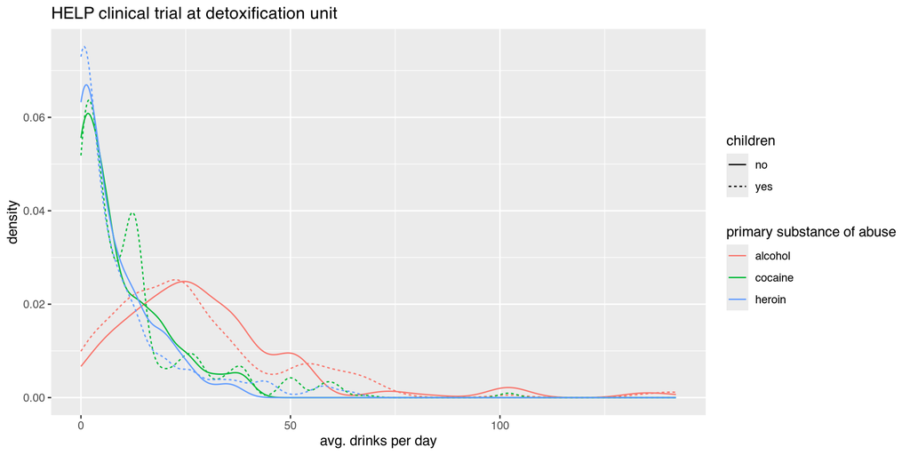

## Using color and facets

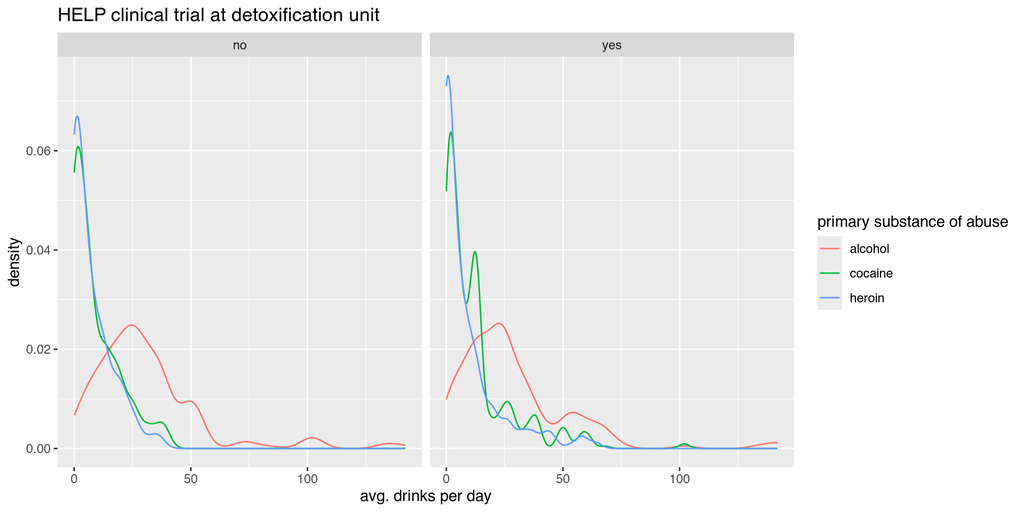

```r
ggplot(data = HELP_data,
       aes(x = i1, color = substance)) +
  geom_line(stat = "density") +
  facet_grid( . ~ children ) +
  labs(title = "HELP clinical trial at detoxification unit")
```

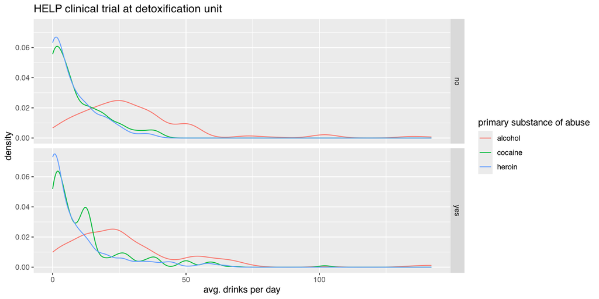

```r
ggplot(data = HELP_data,
       aes(x = i1, color = substance)) +
  geom_line(stat = "density") +
  facet_grid( children ~ . ) +
  labs(title = "HELP clinical trial at detoxification unit")
```

## Boxplots

Boxplots use `stat_quantile()` (five number summary).

The quantitative variable must be `y`, and there must be an additional `x` variable.

```r
HELP_data |>
  ggplot(aes(x = substance, y = age, color = children)) +
  geom_boxplot() +
  labs(title = "HELP clinical trial at detoxification unit")
```

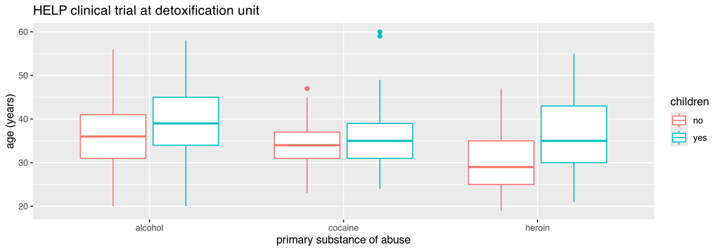

## Horizontal boxplots

Horizontal boxplots are obtained by flipping the coordinate system:

- `coord_flip()` may be used with other plots as well to reverse the roles of `x` and `y` on the plot.

```r
ggplot(data = HELP_data,
       aes(x = substance,
           y = age,
           color = children)) +
  geom_boxplot() +
  coord_flip() +
  labs(title = "HELP clinical trial at detoxification unit")
```

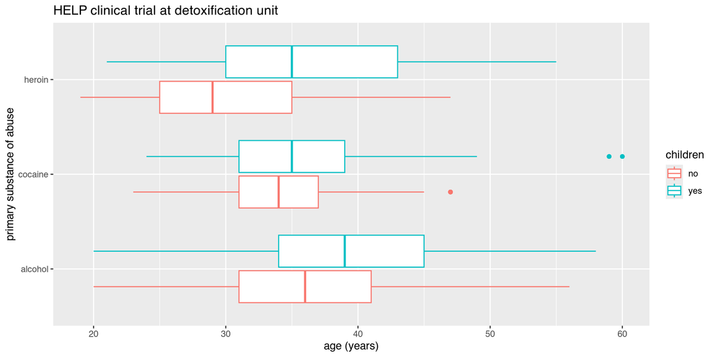

## Axes scaling with boxplots

We can scale the continuous axis

```r
ggplot(data = HELP_data,
       aes(x = substance,
           y = age,
           color = children)) +
  geom_boxplot() +
  coord_trans(y = "exp") +
  labs(title = "HELP clinical trial at detoxification unit")
```

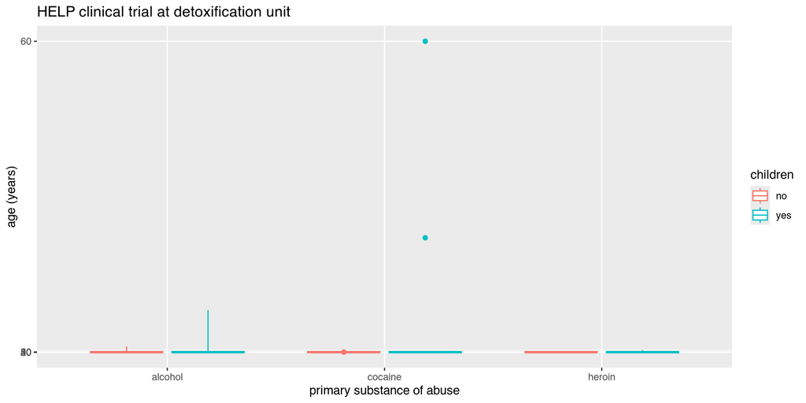

## Give me some space

We’ve triggered a new feature: `dodge` (for dodging things left/right). We can control how much if we set the dodge manually.

```r
ggplot(data = HELP_data,
       aes(x = substance,
           y = age,
           color = children)) +
  geom_boxplot(position = position_dodge(width=1)) +
  labs(title = "HELP clinical trial at detoxification unit")
```

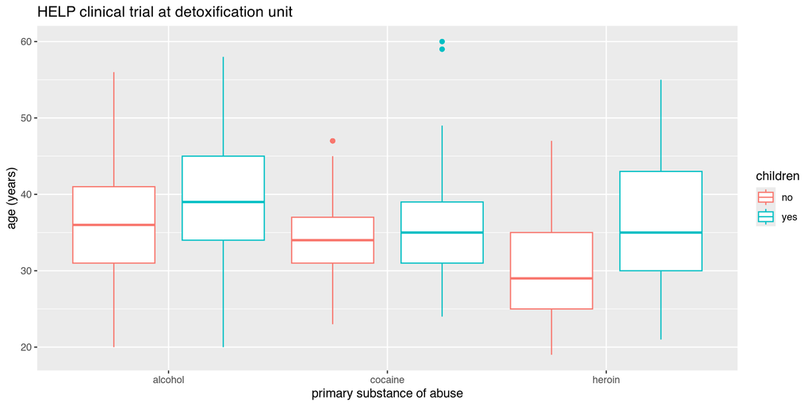

## Issues with bigger data

- Although we can see a generally positive association (as we would expect), the overplotting may be hiding information.

```r
library(NHANES)
dim(NHANES)
```

```
[1] 10000    76
```

```r
ggplot(data = NHANES,
       aes(x = Height, y = Weight)) +
  geom_point() +
  facet_grid( Gender ~ PregnantNow )
```

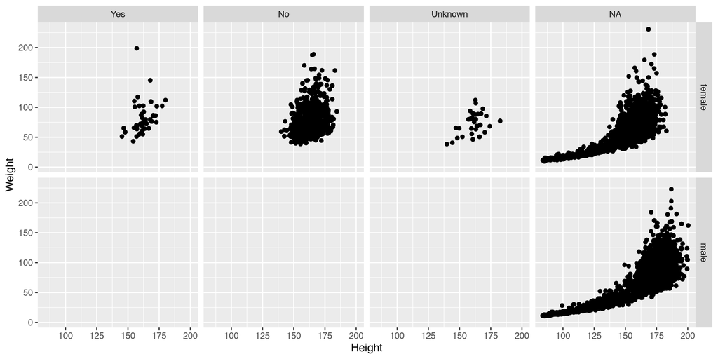

## Using alpha (opacity)

One way to deal with overplotting is to set the opacity low.

```r
ggplot(data = NHANES,
       aes(x = Height, y = Weight)) +
  geom_point(alpha=0.01) +
  facet_grid( Gender ~ PregnantNow )
```

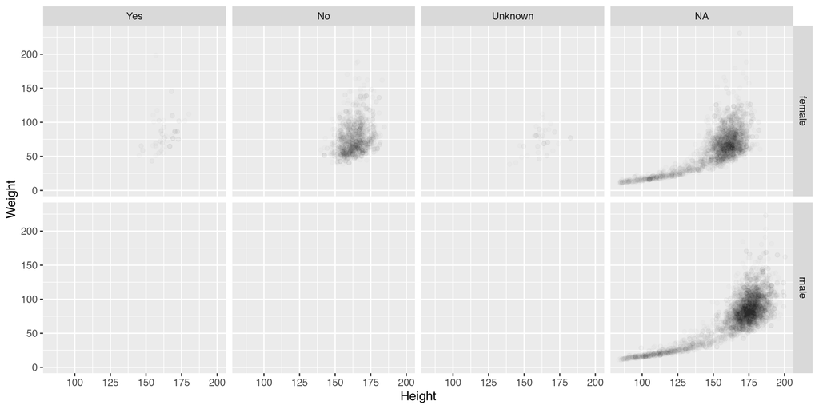

## geom_density2d

Alternatively (or simultaneously) we might prefer a different geom altogether.

```r
ggplot(data = NHANES,
       aes(x = Height, y = Weight)) +
  geom_density2d() +
  facet_grid( Gender ~ PregnantNow )
```

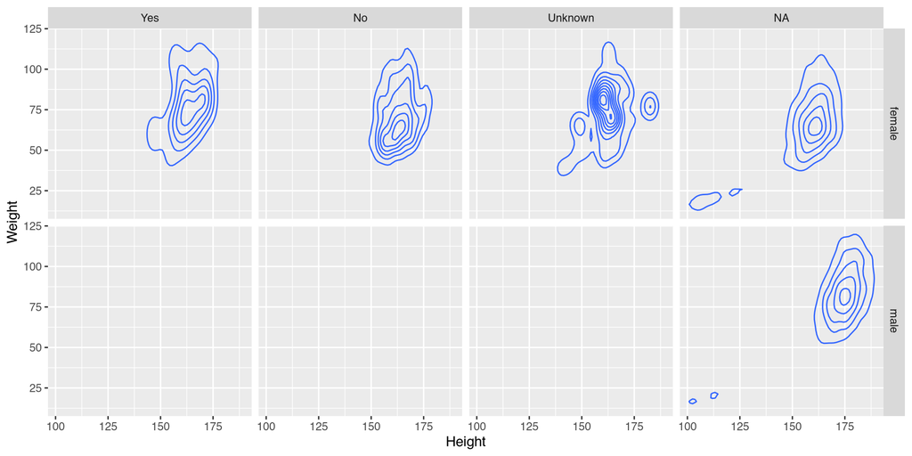

## Multiple layers

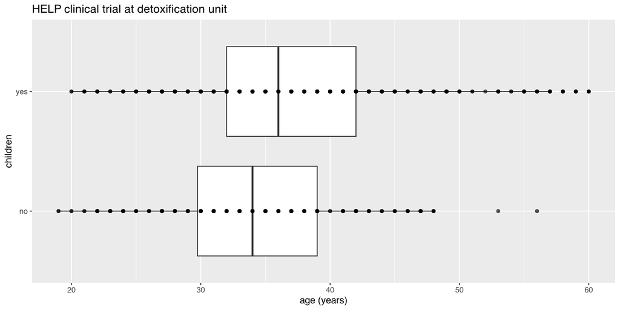

```r
ggplot(data = HELP_data,
       aes(x = children, y = age)) +
  geom_boxplot(outlier.size = 0) +
  geom_point(alpha=.6) +
  coord_flip() +
  labs(title = "HELP clinical trial at detoxification unit")
```

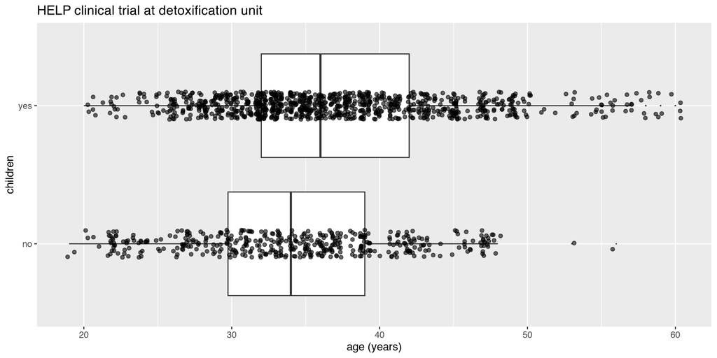

```r
ggplot(data = HELP_data,
       aes(x = children, y = age)) +
  geom_boxplot(outlier.size = 0) +
  geom_jitter(alpha=.6, width = 0.1) +
  coord_flip() +
  labs(title = "HELP clinical trial at detoxification unit")
```

## Multiple layers

```r
ggplot(data = HELP_data,
       aes(x = children, y = age)) +
  geom_boxplot(outlier.size = 0) +
  geom_point(alpha=.6,
             position = position_jitter(width=.1, height=0)) +
  coord_flip() +
  labs(title = "HELP clinical trial at detoxification unit")
```

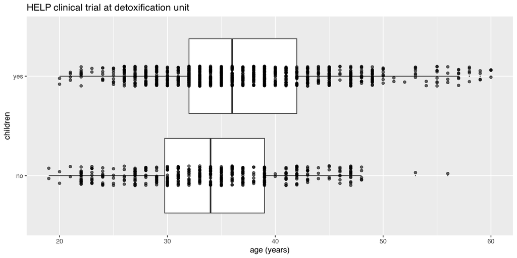

## Things I haven’t mentioned (much)

- coords (`coord_flip()` is good to know about)
- themes (for customizing appearance)
- position (`position_dodge()`, `position_jitterdodge()`, `position_stack()`, etc.)
- transforming axes

## themes

```r
library(ggthemes)
ggplot(Births2015, aes(x = date, y = births)) +
  geom_point() +
  theme_wsj()
```

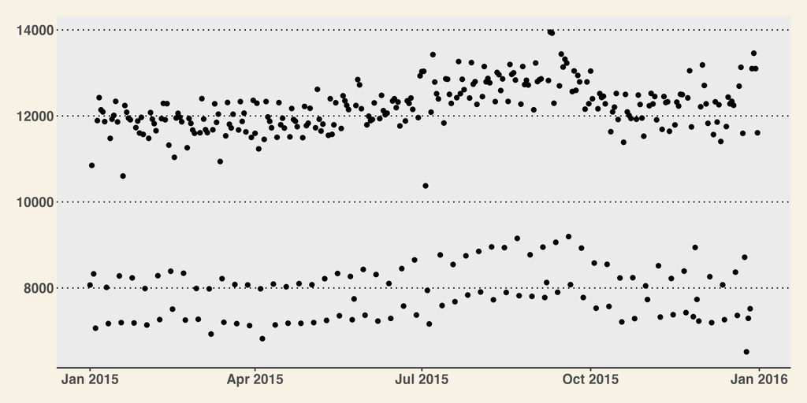

## `jitterdodge()`

```r
ggplot(data = HELP_data,
       aes(x = substance, y = age, color = children)) +
  geom_boxplot(coef = 10, position = position_dodge()) +
  geom_point(aes(color = children,
                 fill = children),
             position = position_jitterdodge()) +
  labs(title = "HELP clinical trial at detoxification unit")
```

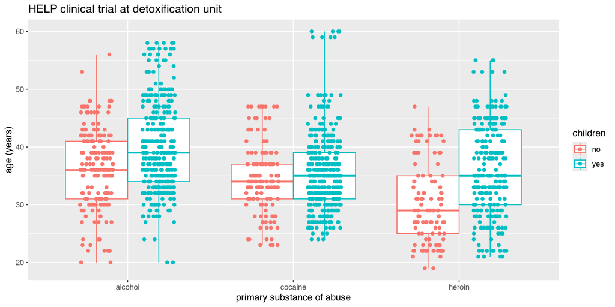

## A little bit of everything

```r
ggplot(data = HELP_data, aes(x = substance, y = age, color = children)) +
  geom_boxplot(coef = 10, position = position_dodge(width=1)) +
  geom_point(aes(fill = children), alpha=.5,
             position = position_jitterdodge(dodge.width=1, jitter.width = 0.2)) +
  facet_wrap(~homeless) +
  labs(title = "HELP clinical trial at detoxification unit")
```

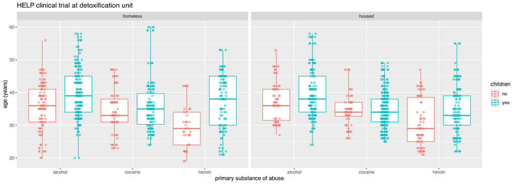

## Want to learn more?

- docs.ggplot2.org/
- [R for Data Science](https://r4ds.had.co.nz/) by Hadley Wickham and Garrett Grolemund